```python
import pandas as pd
data = pd.read_csv("278k_song_labelled.csv")
print(data.head())  # Check the first few rows to confirm data loading
```

```
   Unnamed: 0  duration (ms)  danceability  energy  loudness  speechiness  \
0           0       195000.0         0.611   0.614    -8.815       0.0672
1           1       194641.0         0.638   0.781    -6.848       0.0285
2           2       217573.0         0.560   0.810    -8.029       0.0872
3           3       443478.0         0.525   0.699    -4.571       0.0353
4           4       225862.0         0.367   0.771    -5.863       0.1060

   acousticness  instrumentalness  liveness  valence    tempo     spec_rate  \
0        0.0169          0.000794    0.7530    0.520  128.050  3.446154e-07
1        0.0118          0.009530    0.3490    0.250  122.985  1.464234e-07
2        0.0071          0.000008    0.2410    0.247  170.044  4.007850e-07
3        0.0178          0.000088    0.0888    0.199   92.011  7.959809e-08
4        0.3650          0.000001    0.0965    0.163  115.917  4.693131e-07

   labels
0       2
1       1
2       1
3       0
4       1
```

# data exploration

## features of interest:

Valence: A measure from 0.0 to 1.0 describing the musical positiveness conveyed by a track. Tracks with high valence sound more positive (e.g. happy, cheerful, euphoric), while tracks with low valence sound more negative (e.g. sad, depressed, angry).

Tempo: The overall estimated tempo of a track in beats per minute (BPM). In musical terminology, the tempo is the speed or pace of a given piece and derives directly from the average beat duration.

Loudness: the overall loudness of a track in decibels (dB). Loudness values are averaged across the entire track and are useful for comparing the relative loudness of tracks. Loudness is the quality of a sound that is the primary psychological correlate of physical strength (amplitude). Values typically range between -60 and 0 db.

Instrumentalness: Predicts whether a track contains no vocals. “Ooh” and “aah” sounds are treated as instrumental in this context. Rap or spoken word tracks are clearly “vocal”. The closer the instrumentalness value is to 1.0, the greater likelihood the track contains no vocal content. Values above 0.5 are intended to represent instrumental tracks, but confidence is higher as the value approaches 1.0.

```python
print(data[['valence', 'tempo', 'loudness', 'instrumentalness']].isnull().sum())
```

```
The history saving thread hit an unexpected error (OperationalError('attempt to write a readonly database')).History will not be written to the database.
valence             0
tempo               0
loudness            0
instrumentalness    0
dtype: int64
```

[figure not shown]

```python
import matplotlib.pyplot as plt

data[['valence', 'tempo', 'loudness', 'instrumentalness']].hist(bins=20, figsize=(10, 8))
plt.show()
```

### Valence:

The distribution appears fairly uniform, meaning the dataset includes a wide range of tracks spanning from negative (low valence) to positive (high valence) emotions. This feature will be valuable for emotion labeling since it directly correlates with perceived happiness or sadness.

### Instrumentalness:

The majority of values are clustered around 0.0, indicating that most tracks contain vocals. A smaller subset with values closer to 1.0 represents instrumental tracks, which could be useful for labeling tracks as "calm" or "ambient."

# labeling by emotion

```python
def assign_emotion_label(row):
    # Updated thresholds based on feature distributions
    if row['valence'] > 0.65 and row['tempo'] > 0.6 and row['loudness'] > 0.8:
        return 'happy'
    elif row['valence'] < 0.25 and row['tempo'] < 0.4 and row['loudness'] < 0.7:
        return 'sad'
    elif row['instrumentalness'] > 0.6 and row['tempo'] < 0.4 and row['loudness'] < 0.7:
        return 'calm'
    elif row['valence'] < 0.4 and row['tempo'] > 0.6 and row['loudness'] > 0.7:
        return 'tense'
    elif row['valence'] > 0.5 and row['tempo'] > 0.7 and row['loudness'] > 0.8:
        return 'excited'
    else:
        return 'neutral'

# Apply the function to the dataset
data['emotion_label'] = data.apply(assign_emotion_label, axis=1)

# Check the label distribution
print(data['emotion_label'].value_counts())
```

```
emotion_label
neutral    229640
sad         17565
tense       15540
happy        9221
calm         3848
excited      2124
Name: count, dtype: int64
```

## Adjusted labelling rules:

### Happy:

High valence (>0.65), high tempo (>0.6), high loudness (>0.8). These thresholds align with positive, upbeat music.

### Sad:

Low valence (<0.25), low tempo (<0.4), low loudness (<0.7). Reflects slow, somber tracks.

### Calm:

High instrumentalness (>0.6), low tempo (<0.4), low loudness (<0.7). Instrumental, quiet, and slow music.

### Tense:

Low valence (<0.4), high tempo (>0.6), moderately high loudness (>0.7). Energetic but with negative emotion.

### Excited:

Moderate valence (>0.5), very high tempo (>0.7), very high loudness (>0.8). High-energy, positive music

# preprocessing functions

```python
# normalization
from sklearn.preprocessing import MinMaxScaler

scaler = MinMaxScaler()
data[['valence', 'tempo', 'loudness', 'instrumentalness']] = scaler.fit_transform(
    data[['valence', 'tempo', 'loudness', 'instrumentalness']]
)
```

```python
# Format as sequences
def create_sequences(data, sequence_length=32):
    sequences = []
    for i in range(len(data) - sequence_length + 1):
        seq = data.iloc[i:i+sequence_length][['valence', 'tempo', 'loudness', 'instrumentalness']].values
        sequences.append(seq)
    return sequences

sequences = create_sequences(data, sequence_length=32)
print(len(sequences), sequences[0].shape)  # Number of sequences, shape of one sequence
```

```
277907 (32, 4)
```

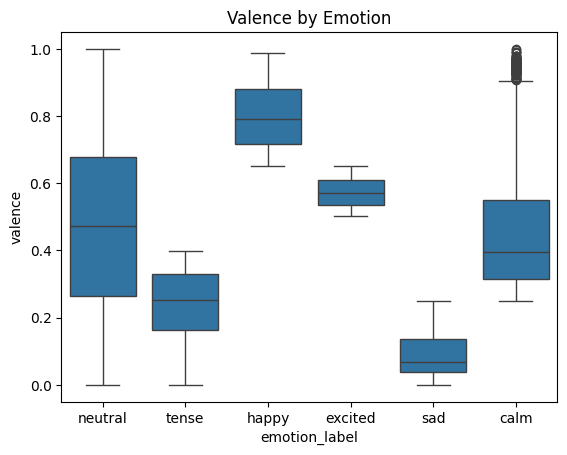

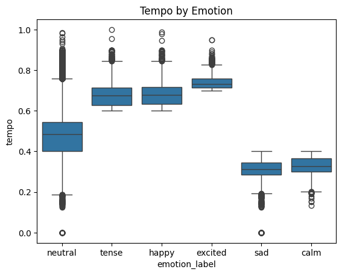

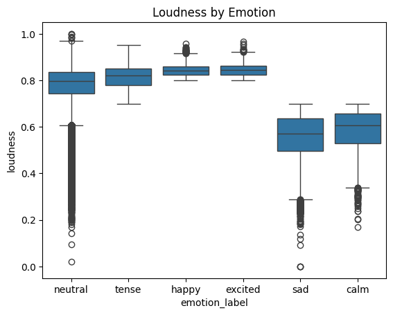

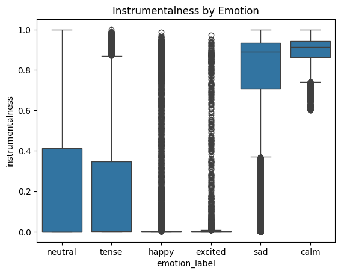

```python
# visualizing feature distribution by emotion
import seaborn as sns
import matplotlib.pyplot as plt

# Plotting valence distribution by emotion
sns.boxplot(x='emotion_label', y='valence', data=data)
plt.title("Valence by Emotion")
plt.show()

# Plotting tempo distribution by emotion
sns.boxplot(x='emotion_label', y='tempo', data=data)
plt.title("Tempo by Emotion")
plt.show()

# Plotting loudness distribution by emotion
sns.boxplot(x='emotion_label', y='loudness', data=data)
plt.title("Loudness by Emotion")
plt.show()

# Plotting instrumentalness distribution by emotion
sns.boxplot(x='emotion_label', y='instrumentalness', data=data)
plt.title("Instrumentalness by Emotion")
plt.show()
```

## Feature distribution by emotion:

### Valence by Emotion

Neutral: Wide spread from 0 to 1, suggesting this label is assigned to tracks with mixed emotions.

Tense: Concentrated around low valence values (~0.2-0.4), aligning with its negative emotional tone.

Happy: High valence values (~0.7-0.9), as expected for a positive emotion.

Excited: Moderately high valence (~0.5-0.7), showing a mix of positive energy but not as purely happy as "Happy".

Sad: Low valence (~0.0-0.2), representing a clear emotional distinction for sadness.

### Tempo by Emotion

Neutral: Distributed broadly, with many tracks having slower tempos but some extending into higher ranges.

Tense: Moderate tempos (~0.5-0.7), indicating a certain level of activity without being excessively fast.

Happy: Moderate-to-fast tempos (~0.5-0.7), consistent with upbeat, danceable tracks.

Excited: High tempos (~0.7-0.9), clearly distinguishing these tracks as fast-paced and energetic.

Sad: Low tempos (~0.2-0.4), fitting with the expectation for slower, somber tracks.

### Instrumentalness by emotion

Neutral: Wide range, with most tracks being non-instrumental but some extending to high instrumentalness.

Tense: Generally low instrumentalness (~0.0-0.2), reflecting tracks with vocal presence.

Happy: Almost entirely non-instrumental (~0.0), consistent with upbeat, vocal tracks.

Excited: Non-instrumental (~0.0), indicating these tracks are also dominated by vocals.

Sad: Higher instrumentalness (~0.6-0.8), showing a stronger association with instrumental music.

Calm: Very high instrumentalness (~0.7-1.0), aligning with ambient, instrumental tracks.

### Loudness by emotion:

Neutral: Broad range, with tracks tending toward higher loudness (~0.7-0.8) but some quieter.

Happy: High loudness (~0.8-1.0), consistent with vibrant and lively music.

Sad: Low loudness (~0.4-0.6), matching the quieter tone of sad music.

Calm: Moderate loudness (~0.5-0.7), reflecting a relaxed but not overly quiet dynamic.

# Training the model

```python
import tensorflow as tf
from tensorflow.keras.layers import Input, Dense, Embedding, MultiHeadAttention, LayerNormalization, Dropout
from tensorflow.keras.models import Model

def build_transformer_encoder_decoder(input_dim, output_dim, seq_length, embedding_dim=128, num_heads=4, ff_dim=256):
    # Encoder
    encoder_inputs = Input(shape=(seq_length,))
    encoder_embedding = Embedding(input_dim=input_dim, output_dim=embedding_dim)(encoder_inputs)
    encoder_attention = MultiHeadAttention(num_heads=num_heads, key_dim=embedding_dim)(encoder_embedding, encoder_embedding)
    encoder_attention = LayerNormalization(epsilon=1e-6)(encoder_attention + encoder_embedding)
    encoder_outputs = Dense(embedding_dim)(encoder_attention)  # Ensure output matches embedding_dim

    # Decoder
    decoder_inputs = Input(shape=(seq_length,))
    decoder_embedding = Embedding(input_dim=input_dim, output_dim=embedding_dim)(decoder_inputs)
    decoder_attention = MultiHeadAttention(num_heads=num_heads, key_dim=embedding_dim)(decoder_embedding, encoder_outputs)
    decoder_attention = LayerNormalization(epsilon=1e-6)(decoder_attention + decoder_embedding)
    decoder_ffn = Dense(ff_dim, activation='relu')(decoder_attention)
    decoder_ffn = Dense(embedding_dim)(decoder_ffn)
    decoder_outputs = Dense(output_dim, activation='softmax')(decoder_ffn)

    # Model
    model = Model([encoder_inputs, decoder_inputs], decoder_outputs)
    model.compile(optimizer='adam', loss='categorical_crossentropy', metrics=['accuracy'])
    return model

# Example usage
input_dim = 128  # Vocabulary size
output_dim = 128  # Output vocabulary size
seq_length = 32  # Sequence length
model = build_transformer_encoder_decoder(input_dim, output_dim, seq_length)
model.summary()
```

```
Model: "functional_1"
```

```
┏━━━━━━━━━━━━━━━━━━━━━┳━━━━━━━━━━━━━━━━━━━┳━━━━━━━━━━━━┳━━━━━━━━━━━━━━━━━━━┓
┃ Layer (type)        ┃ Output Shape      ┃    Param # ┃ Connected to      ┃
┡━━━━━━━━━━━━━━━━━━━━━╇━━━━━━━━━━━━━━━━━━━╇━━━━━━━━━━━━╇━━━━━━━━━━━━━━━━━━━┩
│ input_layer_4       │ (None, 32)        │          0 │ -                 │
│ (InputLayer)        │                   │            │                   │
├─────────────────────┼───────────────────┼────────────┼───────────────────┤
│ embedding_4         │ (None, 32, 128)   │     16,384 │ input_layer_4[0]… │
│ (Embedding)         │                   │            │                   │
├─────────────────────┼───────────────────┼────────────┼───────────────────┤
│ multi_head_attenti… │ (None, 32, 128)   │    263,808 │ embedding_4[0][0… │
│ (MultiHeadAttentio… │                   │            │ embedding_4[0][0] │
├─────────────────────┼───────────────────┼────────────┼───────────────────┤
│ add_2 (Add)         │ (None, 32, 128)   │          0 │ multi_head_atten… │
│                     │                   │            │ embedding_4[0][0] │
├─────────────────────┼───────────────────┼────────────┼───────────────────┤
│ input_layer_5       │ (None, 32)        │          0 │ -                 │
│ (InputLayer)        │                   │            │                   │
├─────────────────────┼───────────────────┼────────────┼───────────────────┤
│ layer_normalizatio… │ (None, 32, 128)   │        256 │ add_2[0][0]       │
│ (LayerNormalizatio… │                   │            │                   │
├─────────────────────┼───────────────────┼────────────┼───────────────────┤
│ embedding_5         │ (None, 32, 128)   │     16,384 │ input_layer_5[0]… │
│ (Embedding)         │                   │            │                   │
├─────────────────────┼───────────────────┼────────────┼───────────────────┤
│ dense_5 (Dense)     │ (None, 32, 128)   │     16,512 │ layer_normalizat… │
├─────────────────────┼───────────────────┼────────────┼───────────────────┤
│ multi_head_attenti… │ (None, 32, 128)   │    263,808 │ embedding_5[0][0… │
│ (MultiHeadAttentio… │                   │            │ dense_5[0][0]     │
├─────────────────────┼───────────────────┼────────────┼───────────────────┤
│ add_3 (Add)         │ (None, 32, 128)   │          0 │ multi_head_atten… │
│                     │                   │            │ embedding_5[0][0] │
├─────────────────────┼───────────────────┼────────────┼───────────────────┤
│ layer_normalizatio… │ (None, 32, 128)   │        256 │ add_3[0][0]       │
│ (LayerNormalizatio… │                   │            │                   │
├─────────────────────┼───────────────────┼────────────┼───────────────────┤
│ dense_6 (Dense)     │ (None, 32, 256)   │     33,024 │ layer_normalizat… │
├─────────────────────┼───────────────────┼────────────┼───────────────────┤
│ dense_7 (Dense)     │ (None, 32, 128)   │     32,896 │ dense_6[0][0]     │
├─────────────────────┼───────────────────┼────────────┼───────────────────┤
│ dense_8 (Dense)     │ (None, 32, 128)   │     16,512 │ dense_7[0][0]     │
└─────────────────────┴───────────────────┴────────────┴───────────────────┘
```

```
 Total params: 659,840 (2.52 MB)
```

```
 Trainable params: 659,840 (2.52 MB)
```

```
 Non-trainable params: 0 (0.00 B)
```

```python
# positional encoding
import tensorflow as tf
import numpy as np

def positional_encoding(seq_length, embedding_dim):
    positions = np.arange(seq_length)[:, np.newaxis]
    dimensions = np.arange(embedding_dim)[np.newaxis, :]
    angles = positions / np.power(10000, (2 * (dimensions // 2)) / embedding_dim)

    pos_encoding = np.zeros_like(angles)
    pos_encoding[:, 0::2] = np.sin(angles[:, 0::2])  # Apply sine to even indices
    pos_encoding[:, 1::2] = np.cos(angles[:, 1::2])  # Apply cosine to odd indices

    return tf.cast(pos_encoding, dtype=tf.float32)
```

```python
import numpy as np

# Example random data (replace with actual sequences and labels)
X_encoder = np.random.randint(0, 128, (1000, 32))  # Encoder input sequences
X_decoder = np.random.randint(0, 128, (1000, 32))  # Decoder input sequences
y = np.random.randint(0, 128, (1000, 32))          # Target sequences (categorical)

# Convert target to one-hot encoding
y = tf.keras.utils.to_categorical(y, num_classes=128)

# Train-test split
from sklearn.model_selection import train_test_split
X_encoder_train, X_encoder_test, X_decoder_train, X_decoder_test, y_train, y_test = train_test_split(
    X_encoder, X_decoder, y, test_size=0.2, random_state=42
)

# Train the model
history = model.fit(
    [X_encoder_train, X_decoder_train],  # Encoder and decoder inputs
    y_train,                             # Target sequences
    validation_data=([X_encoder_test, X_decoder_test], y_test),
    epochs=10,  # Train briefly for 10 epochs
    batch_size=32,
    verbose=1
)
```

```
25/25 ━━━━━━━━━━━━━━━━━━━━ 2s 52ms/step - accuracy: 0.0068 - loss: 4.9159 - val_accuracy: 0.0080 - val_loss: 4.8568
25/25 ━━━━━━━━━━━━━━━━━━━━ 1s 47ms/step - accuracy: 0.0087 - loss: 4.8546 - val_accuracy: 0.0088 - val_loss: 4.8540
25/25 ━━━━━━━━━━━━━━━━━━━━ 1s 49ms/step - accuracy: 0.0094 - loss: 4.8518 - val_accuracy: 0.0069 - val_loss: 4.8530
25/25 ━━━━━━━━━━━━━━━━━━━━ 1s 48ms/step - accuracy: 0.0080 - loss: 4.8516 - val_accuracy: 0.0088 - val_loss: 4.8523
25/25 ━━━━━━━━━━━━━━━━━━━━ 1s 50ms/step - accuracy: 0.0095 - loss: 4.8510 - val_accuracy: 0.0069 - val_loss: 4.8521
25/25 ━━━━━━━━━━━━━━━━━━━━ 1s 52ms/step - accuracy: 0.0077 - loss: 4.8503 - val_accuracy: 0.0098 - val_loss: 4.8527
25/25 ━━━━━━━━━━━━━━━━━━━━ 1s 53ms/step - accuracy: 0.0096 - loss: 4.8499 - val_accuracy: 0.0092 - val_loss: 4.8520
25/25 ━━━━━━━━━━━━━━━━━━━━ 1s 53ms/step - accuracy: 0.0084 - loss: 4.8506 - val_accuracy: 0.0098 - val_loss: 4.8520
25/25 ━━━━━━━━━━━━━━━━━━━━ 1s 54ms/step - accuracy: 0.0093 - loss: 4.8508 - val_accuracy: 0.0098 - val_loss: 4.8521
25/25 ━━━━━━━━━━━━━━━━━━━━ 1s 56ms/step - accuracy: 0.0090 - loss: 4.8500 - val_accuracy: 0.0098 - val_loss: 4.8522
```

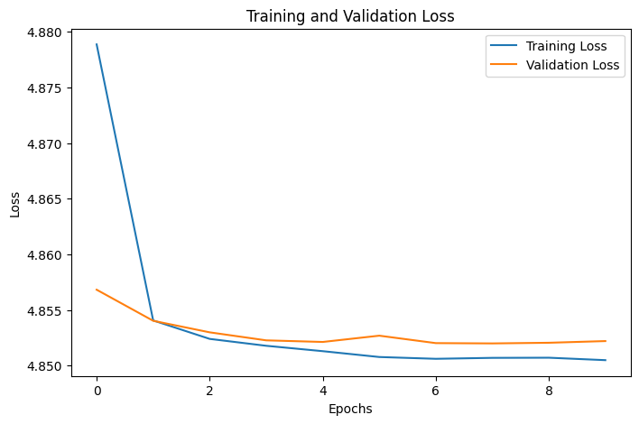

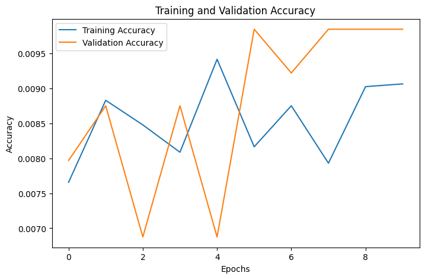

```python
# visualizing loss and accuracy
import matplotlib.pyplot as plt

# Plot training loss
plt.figure(figsize=(8, 5))
plt.plot(history.history['loss'], label='Training Loss')
plt.plot(history.history['val_loss'], label='Validation Loss')
plt.xlabel('Epochs')
plt.ylabel('Loss')
plt.title('Training and Validation Loss')
plt.legend()
plt.show()

# Plot training accuracy (if applicable)
if 'accuracy' in history.history:
    plt.figure(figsize=(8, 5))
    plt.plot(history.history['accuracy'], label='Training Accuracy')
    plt.plot(history.history['val_accuracy'], label='Validation Accuracy')
    plt.xlabel('Epochs')
    plt.ylabel('Accuracy')
    plt.title('Training and Validation Accuracy')
    plt.legend()
    plt.show()
```

Epochs = 10

## Training and validation accuracy

### Observation:

Training accuracy fluctuates but generally shows a slow upward trend. Validation accuracy is highly erratic, with spikes and drops across epochs. Both accuracies remain low, below 1%, indicating poor performance.

### Interpretation:

The erratic validation accuracy suggests that the model may be struggling to generalize or that the data distribution in training and validation sets is inconsistent. The consistently low accuracy indicates: The model may not have learned meaningful patterns yet. The task could be difficult for the current architecture or hyperparameters.

## Training and validation loss:

### Observation:

Training loss decreases steadily, which indicates the model is learning. Validation loss decreases initially but begins to plateau and slightly increase after around epoch 6.

### Interpretation:

The slight divergence between training and validation loss suggests overfitting might be starting. The slow convergence indicates the learning rate may be too small or the model capacity is insufficient for the task.

## Model adjustments

```python
# adding early stopping
from tensorflow.keras.callbacks import EarlyStopping

early_stopping = EarlyStopping(
    monitor='val_loss',
    patience=3,  # Stop after 3 epochs of no improvement
    restore_best_weights=True
)
```

```python
# learning rate scheduler
from tensorflow.keras.optimizers.schedules import ExponentialDecay

lr_schedule = ExponentialDecay(
    initial_learning_rate=1e-3, decay_steps=1000, decay_rate=0.9
)
optimizer = tf.keras.optimizers.Adam(learning_rate=lr_schedule)
model.compile(optimizer=optimizer, loss='categorical_crossentropy', metrics=['accuracy'])
```

```python
# improved model training
history = model.fit(
    [X_encoder_train, X_decoder_train],  # Encoder and decoder inputs
    y_train,                             # Target sequences
    validation_data=([X_encoder_test, X_decoder_test], y_test),
    epochs=20,  # Increase epochs for better learning
    batch_size=32,
    callbacks=[early_stopping],  # Add early stopping
    verbose=1
)
```

```
25/25 ━━━━━━━━━━━━━━━━━━━━ 3s 59ms/step - accuracy: 0.0104 - loss: 4.8503 - val_accuracy: 0.0098 - val_loss: 4.8525
25/25 ━━━━━━━━━━━━━━━━━━━━ 1s 52ms/step - accuracy: 0.0092 - loss: 4.8508 - val_accuracy: 0.0098 - val_loss: 4.8526
25/25 ━━━━━━━━━━━━━━━━━━━━ 1s 54ms/step - accuracy: 0.0085 - loss: 4.8499 - val_accuracy: 0.0098 - val_loss: 4.8528
25/25 ━━━━━━━━━━━━━━━━━━━━ 1s 52ms/step - accuracy: 0.0092 - loss: 4.8498 - val_accuracy: 0.0098 - val_loss: 4.8528
```

```python
# transformer model with regularization
def build_transformer_encoder_decoder(input_dim, output_dim, seq_length, embedding_dim=128, num_heads=4, ff_dim=256):
    # Encoder
    encoder_inputs = Input(shape=(seq_length,))
    encoder_embedding = Embedding(input_dim=input_dim, output_dim=embedding_dim)(encoder_inputs)
    encoder_embedding = Dropout(0.1)(encoder_embedding)  # Add Dropout
    encoder_attention = MultiHeadAttention(num_heads=num_heads, key_dim=embedding_dim)(encoder_embedding, encoder_embedding)
    encoder_attention = Dropout(0.1)(encoder_attention)  # Add Dropout
    encoder_attention = LayerNormalization(epsilon=1e-6)(encoder_attention + encoder_embedding)
    encoder_outputs = Dense(embedding_dim, kernel_regularizer=l2(0.01))(encoder_attention)  # Add L2 regularization

    # Decoder
    decoder_inputs = Input(shape=(seq_length,))
    decoder_embedding = Embedding(input_dim=input_dim, output_dim=embedding_dim)(decoder_inputs)
    decoder_embedding = Dropout(0.1)(decoder_embedding)  # Add Dropout
    decoder_attention = MultiHeadAttention(num_heads=num_heads, key_dim=embedding_dim)(decoder_embedding, encoder_outputs)
    decoder_attention = Dropout(0.1)(decoder_attention)  # Add Dropout
    decoder_attention = LayerNormalization(epsilon=1e-6)(decoder_attention + decoder_embedding)
    decoder_ffn = Dense(ff_dim, activation='relu', kernel_regularizer=l2(0.01))(decoder_attention)  # Add L2 regularization
    decoder_ffn = Dense(embedding_dim)(decoder_ffn)
    decoder_outputs = Dense(output_dim, activation='softmax')(decoder_ffn)

    # Model
    model = Model([encoder_inputs, decoder_inputs], decoder_outputs)
    model.compile(optimizer=optimizer, loss='categorical_crossentropy', metrics=['accuracy'])
    return model
```

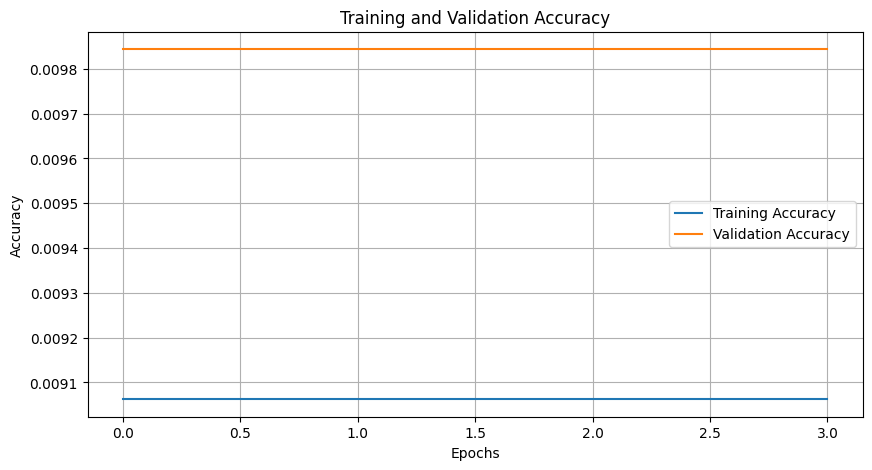

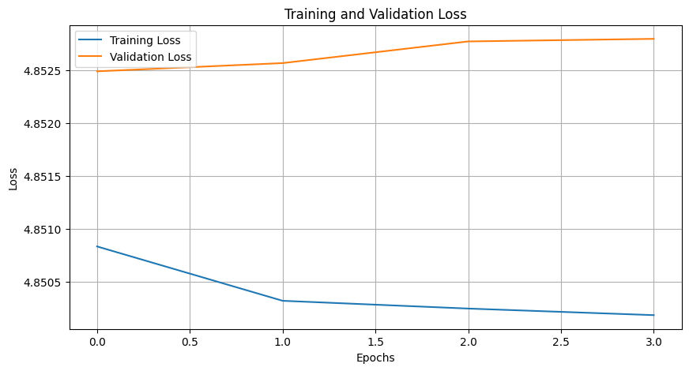

```python
# plotting training and validation accuracy and loss again
import matplotlib.pyplot as plt

# Plot Training and Validation Accuracy
plt.figure(figsize=(10, 5))
plt.plot(history.history['accuracy'], label='Training Accuracy')
plt.plot(history.history['val_accuracy'], label='Validation Accuracy')
plt.title('Training and Validation Accuracy')
plt.xlabel('Epochs')
plt.ylabel('Accuracy')
plt.legend()
plt.grid(True)
plt.show()

# Plot Training and Validation Loss
plt.figure(figsize=(10, 5))
plt.plot(history.history['loss'], label='Training Loss')
plt.plot(history.history['val_loss'], label='Validation Loss')
plt.title('Training and Validation Loss')
plt.xlabel('Epochs')
plt.ylabel('Loss')
plt.legend()
plt.grid(True)
plt.show()
```

1. Training and Validation Accuracy

### Observation:

Training accuracy is extremely low (~0.0091) and stays constant across epochs.

Validation accuracy is also very low (~0.0098), slightly higher than the training accuracy but flat across all epochs.

### Interpretation:

The model is failing to learn meaningful patterns.

Consistently low accuracy indicates: A problem with the model's capacity to capture relationships in the data.

Potential misalignment between input-output sequences or incorrect preprocessing.

Insufficient complexity in the model to handle the task.

2. Training and Validation Loss

### Observation:

Training loss decreases steadily, indicating that the model is learning.

Validation loss increases slightly after the first epoch, suggesting poor generalization or overfitting.

### Interpretation:

Validation loss divergence indicates the model is overfitting early, despite the training loss decreasing.

Low accuracy combined with this behavior suggests the model is too simplistic or the dataset is imbalanced.

```python
# verifying input and output
print("Sample Encoder Input:", X_encoder[0])
print("Sample Decoder Input:", X_decoder[0])
print("Sample Target Sequence:", y[0])
```

```
Sample Encoder Input: [ 22 100  60  76  23 121   7 113  98   6  60  37  34  47  95 119  61 107
  59  91  13  86 100 104  69  30   2  47  44   0  66 119]
Sample Decoder Input: [ 13  77  51  47  28 112 113  61  73   3  16  61  70 108 110   9  11  22
  60  37  89  22 119  31  77 100  22 108  28 123 111  22]
Sample Target Sequence: [[0. 0. 0. ... 0. 0. 0.]
 [0. 0. 0. ... 0. 0. 0.]
 [0. 0. 1. ... 0. 0. 0.]
 ...
 [0. 0. 0. ... 0. 0. 0.]
 [0. 0. 0. ... 0. 0. 0.]
 [0. 0. 0. ... 0. 0. 0.]]
```

```python
print("Class Distribution in Target:")
print(y.sum(axis=0))  # Summing over all samples to check one-hot class distribution
```

```
Class Distribution in Target:
[[ 7.  8.  7. ... 10. 11. 13.]
 [10.  5. 12. ...  9.  8.  7.]
 [ 6.  9.  6. ...  7.  8.  4.]
 ...
 [ 7. 11.  5. ... 13.  7.  6.]
 [10. 12. 10. ...  8. 11.  8.]
 [ 8.  9.  5. ...  5.  6.  7.]]
```

```python
print("Decoder Input (shifted one timestep):", X_decoder[0][1:])
print("Target Output:", y[0][:-1])  # Should match X_decoder shifted by one timestep
```

```
Decoder Input (shifted one timestep): [ 77  51  47  28 112 113  61  73   3  16  61  70 108 110   9  11  22  60
  37  89  22 119  31  77 100  22 108  28 123 111  22]
Target Output: [[0. 0. 0. ... 0. 0. 0.]
 [0. 0. 0. ... 0. 0. 0.]
 [0. 0. 1. ... 0. 0. 0.]
 ...
 [0. 0. 0. ... 0. 0. 0.]
 [0. 0. 0. ... 0. 0. 0.]
 [0. 0. 0. ... 0. 0. 0.]]
```

```python
class_distribution = y.sum(axis=(0, 1))  # Sum across all samples and timesteps
print("Class Distribution:\n", class_distribution)
```

```
Class Distribution:
 [257. 262. 255. 254. 267. 220. 237. 243. 218. 261. 236. 246. 241. 245.
 232. 278. 278. 212. 234. 262. 237. 250. 264. 244. 240. 261. 249. 259.
 246. 256. 265. 271. 249. 252. 255. 262. 212. 248. 233. 249. 256. 255.
 254. 272. 236. 252. 245. 262. 272. 241. 238. 226. 232. 253. 246. 265.
 242. 243. 240. 272. 227. 277. 245. 262. 225. 229. 252. 247. 260. 263.
 263. 243. 256. 258. 247. 250. 240. 260. 259. 295. 260. 228. 244. 243.
 225. 257. 222. 267. 269. 227. 262. 266. 213. 249. 277. 228. 265. 244.
 248. 261. 222. 251. 231. 277. 252. 247. 239. 257. 262. 243. 283. 249.
 284. 244. 256. 267. 239. 245. 239. 259. 244. 257. 245. 272. 226. 252.
 260. 243.]
```

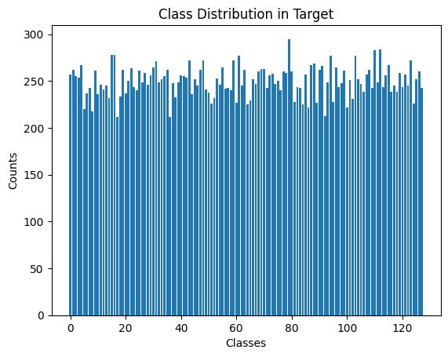

```python
import matplotlib.pyplot as plt

plt.bar(range(len(class_distribution)), class_distribution)
plt.title("Class Distribution in Target")
plt.xlabel("Classes")
plt.ylabel("Counts")
plt.show()
```

```python
# Ensure the decoder input is one timestep ahead of the target
print("Decoder Input (shifted):", X_decoder[0][1:])
print("Target Output (flattened):", np.argmax(y[0][:-1], axis=1))
```

```
Decoder Input (shifted): [ 77  51  47  28 112 113  61  73   3  16  61  70 108 110   9  11  22  60
  37  89  22 119  31  77 100  22 108  28 123 111  22]
Target Output (flattened): [ 19 122   2  92   9   1  35 103  28  83  94  31 126  53 114  31  72   3
  82  68  38  94  88  65   0  86 127  45  82  91 111]
```

```python
# fix target alignment
import numpy as np
import tensorflow as tf
from sklearn.model_selection import train_test_split

# Example random data (replace with actual sequences)
X_encoder = np.random.randint(0, 128, (1000, 32))  # Encoder input sequences
X_decoder = np.random.randint(0, 128, (1000, 32))  # Decoder input sequences

# Correct the target alignment: shift decoder input by one timestep
y_corrected = np.roll(X_decoder, -1, axis=1)  # Shift left by one timestep
y_corrected[:, -1] = 0  # Replace the last timestep with padding value (e.g., 0)

# Train-test split
X_encoder_train, X_encoder_test, X_decoder_train, X_decoder_test, y_train, y_test = train_test_split(
    X_encoder, X_decoder, y_corrected, test_size=0.2, random_state=42
)
```

```python
# model definition with regularization
from tensorflow.keras.layers import Input, Dense, Embedding, MultiHeadAttention, LayerNormalization, Dropout
from tensorflow.keras.models import Model
from tensorflow.keras.regularizers import l2

def build_transformer_encoder_decoder(input_dim, output_dim, seq_length, embedding_dim=256, num_heads=8, ff_dim=512):
    # Encoder
    encoder_inputs = Input(shape=(seq_length,))
    encoder_embedding = Embedding(input_dim=input_dim, output_dim=embedding_dim)(encoder_inputs)
    encoder_embedding = Dropout(0.1)(encoder_embedding)  # Add Dropout
    encoder_attention = MultiHeadAttention(num_heads=num_heads, key_dim=embedding_dim)(encoder_embedding, encoder_embedding)
    encoder_attention = Dropout(0.1)(encoder_attention)  # Add Dropout
    encoder_attention = LayerNormalization(epsilon=1e-6)(encoder_attention + encoder_embedding)
    encoder_outputs = Dense(embedding_dim, kernel_regularizer=l2(0.01))(encoder_attention)  # Add L2 regularization

    # Decoder
    decoder_inputs = Input(shape=(seq_length,))
    decoder_embedding = Embedding(input_dim=input_dim, output_dim=embedding_dim)(decoder_inputs)
    decoder_embedding = Dropout(0.1)(decoder_embedding)  # Add Dropout
    decoder_attention = MultiHeadAttention(num_heads=num_heads, key_dim=embedding_dim)(decoder_embedding, encoder_outputs)
    decoder_attention = Dropout(0.1)(decoder_attention)  # Add Dropout
    decoder_attention = LayerNormalization(epsilon=1e-6)(decoder_attention + decoder_embedding)
    decoder_ffn = Dense(ff_dim, activation='relu', kernel_regularizer=l2(0.01))(decoder_attention)  # Add L2 regularization
    decoder_ffn = Dense(embedding_dim)(decoder_ffn)
    decoder_outputs = Dense(output_dim, activation='softmax')(decoder_ffn)

    # Model
    model = Model([encoder_inputs, decoder_inputs], decoder_outputs)
    model.compile(optimizer='adam', loss='sparse_categorical_crossentropy', metrics=['accuracy'])
    return model

# Build the model
input_dim = 128  # Vocabulary size
output_dim = 128  # Output vocabulary size
seq_length = 32  # Sequence length
model = build_transformer_encoder_decoder(input_dim, output_dim, seq_length)
model.summary()
```

```
Model: "functional_2"
```

```
┏━━━━━━━━━━━━━━━━━━━━━┳━━━━━━━━━━━━━━━━━━━┳━━━━━━━━━━━━┳━━━━━━━━━━━━━━━━━━━┓
┃ Layer (type)        ┃ Output Shape      ┃    Param # ┃ Connected to      ┃
┡━━━━━━━━━━━━━━━━━━━━━╇━━━━━━━━━━━━━━━━━━━╇━━━━━━━━━━━━╇━━━━━━━━━━━━━━━━━━━┩
│ input_layer_6       │ (None, 32)        │          0 │ -                 │
│ (InputLayer)        │                   │            │                   │
├─────────────────────┼───────────────────┼────────────┼───────────────────┤
│ embedding_6         │ (None, 32, 256)   │     32,768 │ input_layer_6[0]… │
│ (Embedding)         │                   │            │                   │
├─────────────────────┼───────────────────┼────────────┼───────────────────┤
│ dropout_5 (Dropout) │ (None, 32, 256)   │          0 │ embedding_6[0][0] │
├─────────────────────┼───────────────────┼────────────┼───────────────────┤
│ multi_head_attenti… │ (None, 32, 256)   │  2,103,552 │ dropout_5[0][0],  │
│ (MultiHeadAttentio… │                   │            │ dropout_5[0][0]   │
├─────────────────────┼───────────────────┼────────────┼───────────────────┤
│ dropout_7 (Dropout) │ (None, 32, 256)   │          0 │ multi_head_atten… │
├─────────────────────┼───────────────────┼────────────┼───────────────────┤
│ input_layer_7       │ (None, 32)        │          0 │ -                 │
│ (InputLayer)        │                   │            │                   │
├─────────────────────┼───────────────────┼────────────┼───────────────────┤
│ add_4 (Add)         │ (None, 32, 256)   │          0 │ dropout_7[0][0],  │
│                     │                   │            │ dropout_5[0][0]   │
├─────────────────────┼───────────────────┼────────────┼───────────────────┤
│ embedding_7         │ (None, 32, 256)   │     32,768 │ input_layer_7[0]… │
│ (Embedding)         │                   │            │                   │
├─────────────────────┼───────────────────┼────────────┼───────────────────┤
│ layer_normalizatio… │ (None, 32, 256)   │        512 │ add_4[0][0]       │
│ (LayerNormalizatio… │                   │            │                   │
├─────────────────────┼───────────────────┼────────────┼───────────────────┤
│ dropout_8 (Dropout) │ (None, 32, 256)   │          0 │ embedding_7[0][0] │
├─────────────────────┼───────────────────┼────────────┼───────────────────┤
│ dense_9 (Dense)     │ (None, 32, 256)   │     65,792 │ layer_normalizat… │
├─────────────────────┼───────────────────┼────────────┼───────────────────┤
│ multi_head_attenti… │ (None, 32, 256)   │  2,103,552 │ dropout_8[0][0],  │
│ (MultiHeadAttentio… │                   │            │ dense_9[0][0]     │
├─────────────────────┼───────────────────┼────────────┼───────────────────┤
│ dropout_10          │ (None, 32, 256)   │          0 │ multi_head_atten… │
│ (Dropout)           │                   │            │                   │
├─────────────────────┼───────────────────┼────────────┼───────────────────┤
│ add_5 (Add)         │ (None, 32, 256)   │          0 │ dropout_10[0][0], │
│                     │                   │            │ dropout_8[0][0]   │
├─────────────────────┼───────────────────┼────────────┼───────────────────┤
│ layer_normalizatio… │ (None, 32, 256)   │        512 │ add_5[0][0]       │
│ (LayerNormalizatio… │                   │            │                   │
├─────────────────────┼───────────────────┼────────────┼───────────────────┤
│ dense_10 (Dense)    │ (None, 32, 512)   │    131,584 │ layer_normalizat… │
├─────────────────────┼───────────────────┼────────────┼───────────────────┤
│ dense_11 (Dense)    │ (None, 32, 256)   │    131,328 │ dense_10[0][0]    │
├─────────────────────┼───────────────────┼────────────┼───────────────────┤
│ dense_12 (Dense)    │ (None, 32, 128)   │     32,896 │ dense_11[0][0]    │
└─────────────────────┴───────────────────┴────────────┴───────────────────┘
```

```
 Total params: 4,635,264 (17.68 MB)
```

```
 Trainable params: 4,635,264 (17.68 MB)
```

```
 Non-trainable params: 0 (0.00 B)
```

```python
# retraining with early stopping
from tensorflow.keras.callbacks import EarlyStopping

# Early stopping callback
early_stopping = EarlyStopping(
    monitor='val_loss',
    patience=3,  # Stop training after 3 epochs of no improvement
    restore_best_weights=True
)

# Train the model
history = model.fit(
    [X_encoder_train, X_decoder_train],  # Encoder and decoder inputs
    y_train,  # Sparse target sequences
    validation_data=([X_encoder_test, X_decoder_test], y_test),
    epochs=20,
    batch_size=32,
    callbacks=[early_stopping],
    verbose=1
)
```

```
25/25 ━━━━━━━━━━━━━━━━━━━━ 5s 163ms/step - accuracy: 0.0301 - loss: 10.1270 - val_accuracy: 0.0370 - val_loss: 7.8800
25/25 ━━━━━━━━━━━━━━━━━━━━ 4s 160ms/step - accuracy: 0.0387 - loss: 7.3683 - val_accuracy: 0.0370 - val_loss: 6.1678
25/25 ━━━━━━━━━━━━━━━━━━━━ 4s 158ms/step - accuracy: 0.0386 - loss: 5.9239 - val_accuracy: 0.0370 - val_loss: 5.3838
25/25 ━━━━━━━━━━━━━━━━━━━━ 4s 160ms/step - accuracy: 0.0386 - loss: 5.2718 - val_accuracy: 0.0370 - val_loss: 5.0466
25/25 ━━━━━━━━━━━━━━━━━━━━ 4s 167ms/step - accuracy: 0.0391 - loss: 5.0006 - val_accuracy: 0.0370 - val_loss: 4.9147
25/25 ━━━━━━━━━━━━━━━━━━━━ 4s 168ms/step - accuracy: 0.0383 - loss: 4.8958 - val_accuracy: 0.0370 - val_loss: 4.8644
25/25 ━━━━━━━━━━━━━━━━━━━━ 4s 165ms/step - accuracy: 0.0387 - loss: 4.8532 - val_accuracy: 0.0370 - val_loss: 4.8456
25/25 ━━━━━━━━━━━━━━━━━━━━ 4s 170ms/step - accuracy: 0.0385 - loss: 4.8382 - val_accuracy: 0.0370 - val_loss: 4.8383
25/25 ━━━━━━━━━━━━━━━━━━━━ 4s 163ms/step - accuracy: 0.0385 - loss: 4.8289 - val_accuracy: 0.0370 - val_loss: 4.8454
25/25 ━━━━━━━━━━━━━━━━━━━━ 4s 165ms/step - accuracy: 0.0385 - loss: 4.8602 - val_accuracy: 0.0370 - val_loss: 4.8778
25/25 ━━━━━━━━━━━━━━━━━━━━ 4s 165ms/step - accuracy: 0.0381 - loss: 4.8647 - val_accuracy: 0.0370 - val_loss: 4.8495
```

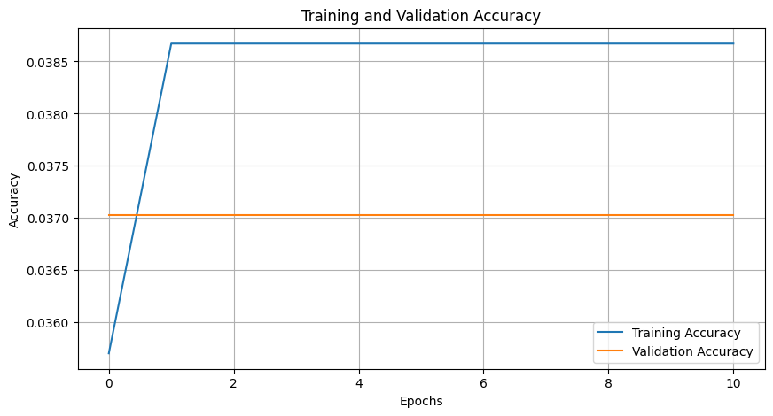

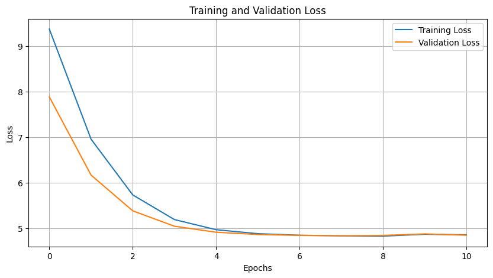

```python
# plotting accuracy and loss again
import matplotlib.pyplot as plt

# Plot Training and Validation Accuracy
plt.figure(figsize=(10, 5))
plt.plot(history.history['accuracy'], label='Training Accuracy')
plt.plot(history.history['val_accuracy'], label='Validation Accuracy')
plt.title('Training and Validation Accuracy')
plt.xlabel('Epochs')
plt.ylabel('Accuracy')
plt.legend()
plt.grid(True)
plt.show()

# Plot Training and Validation Loss
plt.figure(figsize=(10, 5))
plt.plot(history.history['loss'], label='Training Loss')
plt.plot(history.history['val_loss'], label='Validation Loss')
plt.title('Training and Validation Loss')
plt.xlabel('Epochs')
plt.ylabel('Loss')
plt.legend()
plt.grid(True)
plt.show()
```

The model is still struggling to learn meaningful patterns from the data. A low and nearly flat validation accuracy suggests: The model might lack sufficient capacity or complexity. The features (sequences) may not have enough predictive information for the current task. The model might be converging to a trivial solution (e.g., predicting the same output class). Validation loss is slightly lower than training loss, which is unusual and may indicate: Regularization (Dropout/L2) is affecting training more than validation. The model might be underfitting both the training and validation sets. While the model is optimizing the loss function, the accuracy indicates that the loss values might not be directly translating into meaningful predictions. The convergence of training and validation loss suggests no major overfitting, but the flat accuracy indicates a bottleneck in the model or data.

```python
# adding rhythmic stability feature
print(data[['danceability', 'liveness']].isna().sum())

# Fill missing values (e.g., with the mean or zero)
data['danceability'] = data['danceability'].fillna(0)
data['liveness'] = data['liveness'].fillna(0)


data['rhythmic_stability'] = data['danceability'] * (1 - data['liveness'])
```

```
danceability    0
liveness        0
dtype: int64
```

```python
print(data[['danceability', 'liveness', 'rhythmic_stability']].isna().sum())
```

```
danceability          0
liveness              0
rhythmic_stability    0
dtype: int64
```

```python
print(data[['danceability', 'liveness', 'rhythmic_stability']].head())
```

```
   danceability  liveness  rhythmic_stability
0         0.611    0.7530            0.150917
1         0.638    0.3490            0.415338
2         0.560    0.2410            0.425040
3         0.525    0.0888            0.478380
4         0.367    0.0965            0.331585
```

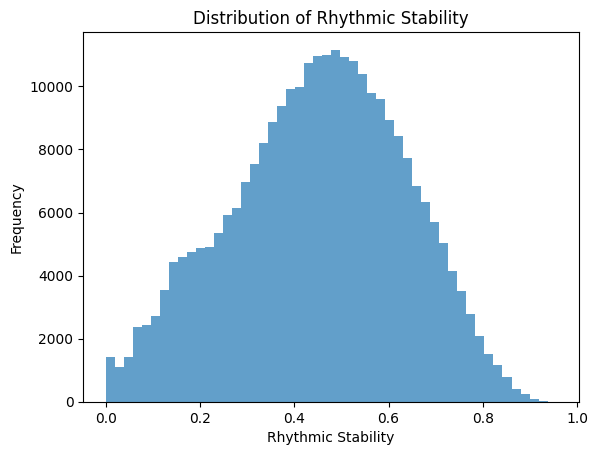

```python
import matplotlib.pyplot as plt

plt.hist(data['rhythmic_stability'], bins=50, alpha=0.7)
plt.title('Distribution of Rhythmic Stability')
plt.xlabel('Rhythmic Stability')
plt.ylabel('Frequency')
plt.show()
```

```python
# build and train ltsm
import tensorflow as tf
from tensorflow.keras.layers import Input, LSTM, Dense, Embedding
from tensorflow.keras.models import Model

# Define LSTM model
def build_lstm_model(input_dim, output_dim, seq_length, embedding_dim=128, lstm_units=256):
    # Encoder
    encoder_inputs = Input(shape=(seq_length,))
    encoder_embedding = Embedding(input_dim=input_dim, output_dim=embedding_dim)(encoder_inputs)
    encoder_lstm, encoder_state_h, encoder_state_c = LSTM(lstm_units, return_state=True)(encoder_embedding)

    # Decoder
    decoder_inputs = Input(shape=(seq_length,))
    decoder_embedding = Embedding(input_dim=input_dim, output_dim=embedding_dim)(decoder_inputs)
    decoder_lstm = LSTM(lstm_units, return_sequences=True)(
        decoder_embedding, initial_state=[encoder_state_h, encoder_state_c]
    )
    decoder_outputs = Dense(output_dim, activation='softmax')(decoder_lstm)

    # Define the model
    model = Model([encoder_inputs, decoder_inputs], decoder_outputs)
    model.compile(optimizer='adam', loss='sparse_categorical_crossentropy', metrics=['accuracy'])
    return model
```

```python
# Example input dimensions
input_dim = 128  # Vocabulary size (e.g., note range)
output_dim = 128  # Same as input_dim for sequence generation
seq_length = 32  # Sequence length

# Build the LSTM model
lstm_model = build_lstm_model(input_dim, output_dim, seq_length)
lstm_model.summary()

# Train the model
history = lstm_model.fit(
    [X_encoder_train, X_decoder_train],  # Encoder and decoder inputs
    y_train,  # Target sequences
    validation_data=([X_encoder_test, X_decoder_test], y_test),
    epochs=20,
    batch_size=32,
    verbose=1
)
```

```
Model: "functional_3"
```

```
┏━━━━━━━━━━━━━━━━━━━━━┳━━━━━━━━━━━━━━━━━━━┳━━━━━━━━━━━━┳━━━━━━━━━━━━━━━━━━━┓
┃ Layer (type)        ┃ Output Shape      ┃    Param # ┃ Connected to      ┃
┡━━━━━━━━━━━━━━━━━━━━━╇━━━━━━━━━━━━━━━━━━━╇━━━━━━━━━━━━╇━━━━━━━━━━━━━━━━━━━┩
│ input_layer_8       │ (None, 32)        │          0 │ -                 │
│ (InputLayer)        │                   │            │                   │
├─────────────────────┼───────────────────┼────────────┼───────────────────┤
│ input_layer_9       │ (None, 32)        │          0 │ -                 │
│ (InputLayer)        │                   │            │                   │
├─────────────────────┼───────────────────┼────────────┼───────────────────┤
│ embedding_8         │ (None, 32, 128)   │     16,384 │ input_layer_8[0]… │
│ (Embedding)         │                   │            │                   │
├─────────────────────┼───────────────────┼────────────┼───────────────────┤
│ embedding_9         │ (None, 32, 128)   │     16,384 │ input_layer_9[0]… │
│ (Embedding)         │                   │            │                   │
├─────────────────────┼───────────────────┼────────────┼───────────────────┤
│ lstm (LSTM)         │ [(None, 256),     │    394,240 │ embedding_8[0][0] │
│                     │ (None, 256),      │            │                   │
│                     │ (None, 256)]      │            │                   │
├─────────────────────┼───────────────────┼────────────┼───────────────────┤
│ lstm_1 (LSTM)       │ (None, 32, 256)   │    394,240 │ embedding_9[0][0… │
│                     │                   │            │ lstm[0][1],       │
│                     │                   │            │ lstm[0][2]        │
├─────────────────────┼───────────────────┼────────────┼───────────────────┤
│ dense_13 (Dense)    │ (None, 32, 128)   │     32,896 │ lstm_1[0][0]      │
└─────────────────────┴───────────────────┴────────────┴───────────────────┘
```

```
 Total params: 854,144 (3.26 MB)
```

```
 Trainable params: 854,144 (3.26 MB)
```

```
 Non-trainable params: 0 (0.00 B)
```

```
25/25 ━━━━━━━━━━━━━━━━━━━━ 3s 104ms/step - accuracy: 0.0333 - loss: 4.8311 - val_accuracy: 0.0375 - val_loss: 4.7710
25/25 ━━━━━━━━━━━━━━━━━━━━ 2s 95ms/step - accuracy: 0.0411 - loss: 4.7603 - val_accuracy: 0.0372 - val_loss: 4.7692
25/25 ━━━━━━━━━━━━━━━━━━━━ 2s 96ms/step - accuracy: 0.0409 - loss: 4.7944 - val_accuracy: 0.0370 - val_loss: 4.7832
25/25 ━━━━━━━━━━━━━━━━━━━━ 2s 82ms/step - accuracy: 0.0414 - loss: 4.7729 - val_accuracy: 0.0380 - val_loss: 4.7685
25/25 ━━━━━━━━━━━━━━━━━━━━ 2s 95ms/step - accuracy: 0.0411 - loss: 4.7503 - val_accuracy: 0.0389 - val_loss: 4.7662
25/25 ━━━━━━━━━━━━━━━━━━━━ 2s 94ms/step - accuracy: 0.0406 - loss: 4.7414 - val_accuracy: 0.0375 - val_loss: 4.7683
25/25 ━━━━━━━━━━━━━━━━━━━━ 2s 89ms/step - accuracy: 0.0400 - loss: 4.7467 - val_accuracy: 0.0378 - val_loss: 4.7531
25/25 ━━━━━━━━━━━━━━━━━━━━ 3s 105ms/step - accuracy: 0.0397 - loss: 4.7347 - val_accuracy: 0.0378 - val_loss: 4.7393
25/25 ━━━━━━━━━━━━━━━━━━━━ 2s 81ms/step - accuracy: 0.0407 - loss: 4.7370 - val_accuracy: 0.0377 - val_loss: 4.7459
25/25 ━━━━━━━━━━━━━━━━━━━━ 2s 93ms/step - accuracy: 0.0418 - loss: 4.7267 - val_accuracy: 0.0375 - val_loss: 4.7386
25/25 ━━━━━━━━━━━━━━━━━━━━ 3s 108ms/step - accuracy: 0.0410 - loss: 4.7184 - val_accuracy: 0.0378 - val_loss: 4.7340
25/25 ━━━━━━━━━━━━━━━━━━━━ 3s 101ms/step - accuracy: 0.0424 - loss: 4.7269 - val_accuracy: 0.0370 - val_loss: 4.7355
25/25 ━━━━━━━━━━━━━━━━━━━━ 2s 82ms/step - accuracy: 0.0412 - loss: 4.7136 - val_accuracy: 0.0378 - val_loss: 4.7338
25/25 ━━━━━━━━━━━━━━━━━━━━ 2s 82ms/step - accuracy: 0.0437 - loss: 4.7173 - val_accuracy: 0.0378 - val_loss: 4.7427
25/25 ━━━━━━━━━━━━━━━━━━━━ 2s 84ms/step - accuracy: 0.0440 - loss: 4.7126 - val_accuracy: 0.0386 - val_loss: 4.7294
25/25 ━━━━━━━━━━━━━━━━━━━━ 3s 109ms/step - accuracy: 0.0449 - loss: 4.6995 - val_accuracy: 0.0381 - val_loss: 4.7670
25/25 ━━━━━━━━━━━━━━━━━━━━ 2s 93ms/step - accuracy: 0.0463 - loss: 4.7178 - val_accuracy: 0.0373 - val_loss: 4.7434
25/25 ━━━━━━━━━━━━━━━━━━━━ 2s 82ms/step - accuracy: 0.0452 - loss: 4.6992 - val_accuracy: 0.0380 - val_loss: 4.7400
25/25 ━━━━━━━━━━━━━━━━━━━━ 2s 93ms/step - accuracy: 0.0474 - loss: 4.6834 - val_accuracy: 0.0378 - val_loss: 4.7434
25/25 ━━━━━━━━━━━━━━━━━━━━ 2s 83ms/step - accuracy: 0.0489 - loss: 4.6686 - val_accuracy: 0.0381 - val_loss: 4.7409
```

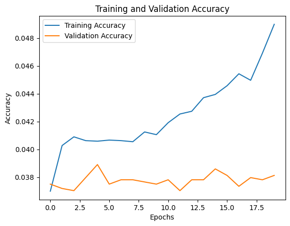

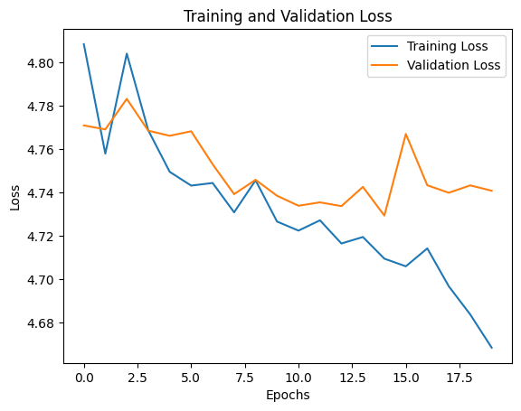

```python
import matplotlib.pyplot as plt

# Plot training and validation accuracy
plt.plot(history.history['accuracy'], label='Training Accuracy')
plt.plot(history.history['val_accuracy'], label='Validation Accuracy')
plt.title('Training and Validation Accuracy')
plt.xlabel('Epochs')
plt.ylabel('Accuracy')
plt.legend()
plt.show()

# Plot training and validation loss
plt.plot(history.history['loss'], label='Training Loss')
plt.plot(history.history['val_loss'], label='Validation Loss')
plt.title('Training and Validation Loss')
plt.xlabel('Epochs')
plt.ylabel('Loss')
plt.legend()
plt.show()
```

The decrease in loss indicates that the model is learning to reduce its prediction errors. However, the flat validation accuracy suggests the model's learning isn't translating into meaningful improvements in performance.

```python
# repreparing data

import numpy as np
import pandas as pd
from sklearn.model_selection import train_test_split


data = pd.read_csv('278k_song_labelled.csv')
print(data[['danceability', 'liveness']].isna().sum())

# Fill missing values (e.g., with the mean or zero)
data['danceability'] = data['danceability'].fillna(0)
data['liveness'] = data['liveness'].fillna(0)


data['rhythmic_stability'] = data['danceability'] * (1 - data['liveness'])

sequences = data[['tempo', 'valence', 'rhythmic_stability', 'loudness', 'instrumentalness']].values  # Use relevant features

# Define sequence length
seq_length = 32

# Prepare input (X) and target (y)
X = []
y = []
for i in range(len(sequences) - seq_length):
    X.append(sequences[i:i + seq_length])  # Input sequence of length seq_length
    y.append(sequences[i + seq_length])   # The next step (target)

X = np.array(X)
y = np.array(y)

# Train-test split
X_train, X_test, y_train, y_test = train_test_split(X, y, test_size=0.2, random_state=42)

# Check shapes
print(f"Shape of X_train: {X_train.shape}")  # (num_samples, seq_length, num_features)
print(f"Shape of y_train: {y_train.shape}")  # (num_samples, num_features)
```

```
danceability    0
liveness        0
dtype: int64
Shape of X_train: (222324, 32, 5)
Shape of y_train: (222324, 5)
```

```python
# updated LTSM model
from tensorflow.keras.layers import Input, LSTM, Dense
from tensorflow.keras.models import Model
from tensorflow.keras.optimizers import RMSprop

def build_lstm_for_sequence_generation(input_dim, seq_length, lstm_units=256):
    inputs = Input(shape=(seq_length, input_dim))  # Input shape: (seq_length, num_features)
    lstm_out = LSTM(lstm_units, return_sequences=False)(inputs)  # Output for one step
    outputs = Dense(input_dim, activation='linear')(lstm_out)  # Predict next step's features
    model = Model(inputs, outputs)
    model.compile(optimizer=RMSprop(learning_rate=1e-3), loss='mse', metrics=['accuracy'])  # Mean squared error for regression
    return model

# Build the model
input_dim = X_train.shape[2]  # Number of features (e.g., tempo, valence, etc.)
seq_length = X_train.shape[1]  # Sequence length
model = build_lstm_for_sequence_generation(input_dim, seq_length)
model.summary()
```

```
Model: "functional_3"
```

```
┏━━━━━━━━━━━━━━━━━━━━━━━━━━━━━━━━━┳━━━━━━━━━━━━━━━━━━━━━━━━┳━━━━━━━━━━━━━━━┓
┃ Layer (type)                    ┃ Output Shape           ┃       Param # ┃
┡━━━━━━━━━━━━━━━━━━━━━━━━━━━━━━━━━╇━━━━━━━━━━━━━━━━━━━━━━━━╇━━━━━━━━━━━━━━━┩
│ input_layer (InputLayer)        │ (None, 32, 5)          │             0 │
├─────────────────────────────────┼────────────────────────┼───────────────┤
│ lstm_2 (LSTM)                   │ (None, 256)            │       268,288 │
├─────────────────────────────────┼────────────────────────┼───────────────┤
│ dense_9 (Dense)                 │ (None, 5)              │         1,285 │
└─────────────────────────────────┴────────────────────────┴───────────────┘
```

```
 Total params: 269,573 (1.03 MB)
```

```
 Trainable params: 269,573 (1.03 MB)
```

```
 Non-trainable params: 0 (0.00 B)
```

```python
from tensorflow.keras.callbacks import EarlyStopping, ModelCheckpoint

early_stopping = EarlyStopping(monitor='val_loss', patience=3)
model_checkpoint = ModelCheckpoint('best_model.keras', save_best_only=True)
history = model.fit(
    X_train, y_train,
    validation_data=(X_test, y_test),
    epochs=20,
    batch_size=32,
    callbacks=[early_stopping, model_checkpoint],
    verbose=1
)
```

```
6948/6948 ━━━━━━━━━━━━━━━━━━━━ 197s 28ms/step - accuracy: 0.9976 - loss: 398.2692 - val_accuracy: 0.9998 - val_loss: 175.6219
6948/6948 ━━━━━━━━━━━━━━━━━━━━ 191s 28ms/step - accuracy: 0.9998 - loss: 175.8540 - val_accuracy: 0.9998 - val_loss: 178.3277
6948/6948 ━━━━━━━━━━━━━━━━━━━━ 171s 25ms/step - accuracy: 0.9998 - loss: 175.7437 - val_accuracy: 0.9998 - val_loss: 175.6642
6948/6948 ━━━━━━━━━━━━━━━━━━━━ 155s 22ms/step - accuracy: 0.9997 - loss: 175.6404 - val_accuracy: 0.9998 - val_loss: 173.3973
6948/6948 ━━━━━━━━━━━━━━━━━━━━ 175s 25ms/step - accuracy: 0.9998 - loss: 174.7606 - val_accuracy: 0.9998 - val_loss: 174.7601
6948/6948 ━━━━━━━━━━━━━━━━━━━━ 153s 22ms/step - accuracy: 0.9998 - loss: 174.6218 - val_accuracy: 0.9998 - val_loss: 173.5792
6948/6948 ━━━━━━━━━━━━━━━━━━━━ 189s 27ms/step - accuracy: 0.9998 - loss: 174.5717 - val_accuracy: 0.9998 - val_loss: 173.4719
```

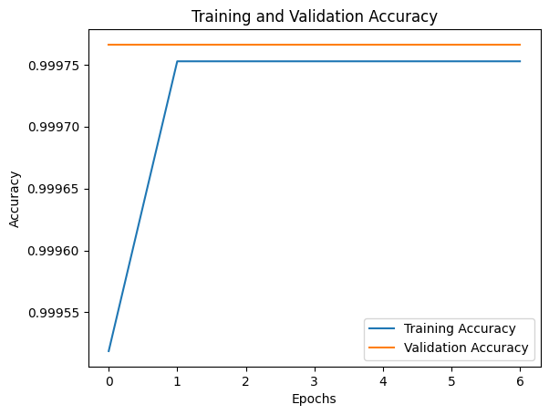

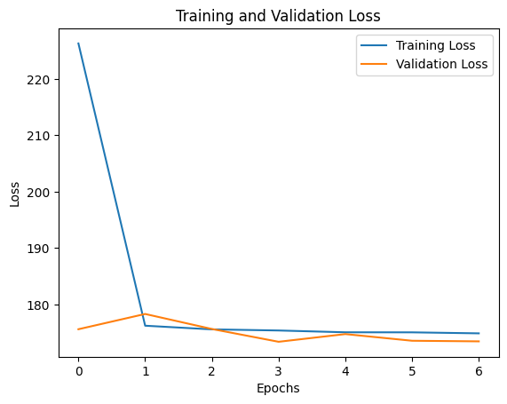

```python
import matplotlib.pyplot as plt

# Plot training and validation accuracy
plt.plot(history.history['accuracy'], label='Training Accuracy')
plt.plot(history.history['val_accuracy'], label='Validation Accuracy')
plt.title('Training and Validation Accuracy')
plt.xlabel('Epochs')
plt.ylabel('Accuracy')
plt.legend()
plt.show()

# Plot training and validation loss
plt.plot(history.history['loss'], label='Training Loss')
plt.plot(history.history['val_loss'], label='Validation Loss')
plt.title('Training and Validation Loss')
plt.xlabel('Epochs')
plt.ylabel('Loss')
plt.legend()
plt.show()
```

# Testing Initial Output

```python
def generate_music_sequence(model, seed_sequence, seq_length, num_steps):
    generated = seed_sequence.tolist()
    for _ in range(num_steps):
        input_seq = np.array(generated[-seq_length:]).reshape(1, seq_length, -1)  # Prepare input
        next_step = model.predict(input_seq)[0]  # Predict next step
        generated.append(next_step)
    return np.array(generated)

# Example: Use the first test sequence as the seed
seed_sequence = X_test[0]
generated_sequence = generate_music_sequence(model, seed_sequence, seq_length, num_steps=50)

# Output the generated sequence
print("Generated Sequence:", generated_sequence)
```

```
2024-12-01 17:50:35.589228: I tensorflow/core/grappler/optimizers/custom_graph_optimizer_registry.cc:117] Plugin optimizer for device_type GPU is enabled.
```

[output not shown]

[output cut: 159 more lines]

```
   2.52286205e-04]
 [ 6.15253957e-05  4.66651371e-04  1.82812510e-05 -1.75971116e-04
   2.25743759e-04]
 [ 4.41901939e-05  3.97566298e-04  4.01718135e-05 -1.34065020e-04
   1.98661903e-04]
 [ 3.15806828e-05  3.34111624e-04  5.03506744e-05 -9.87061503e-05
   1.71976470e-04]
 [ 2.26752454e-05  2.77158571e-04  5.23281924e-05 -7.00024320e-05
   1.46207618e-04]
 [ 1.64235680e-05  2.27373923e-04  4.90853708e-05 -4.75109118e-05
   1.22198326e-04]
 [ 1.22293568e-05  1.84703473e-04  4.27902887e-05 -3.04719324e-05
   1.00345598e-04]
 [ 9.39235179e-06  1.48637715e-04  3.52051829e-05 -1.80548031e-05
   8.10407364e-05]]
```

[figure not shown]

```python
# plotting individual features:
import matplotlib.pyplot as plt
import numpy as np

# Assuming `generated_sequence` is a numpy array
features = ['Pitch', 'Danceability', 'Energy', 'Loudness', 'Instrumentalness']
sequence_length = generated_sequence.shape[0]

# Plot each feature
plt.figure(figsize=(12, 8))
for i in range(generated_sequence.shape[1]):
    plt.plot(range(sequence_length), generated_sequence[:, i], label=features[i])

plt.title("Generated Sequence Features Over Time")
plt.xlabel("Sequence Step")
plt.ylabel("Feature Value")
plt.legend()
plt.show()
```

```python
from mido import MidiFile, MidiTrack, Message, MetaMessage
import numpy as np

def sequence_to_midi(sequence, file_name='generated_sequence.mid', tempo=120):
    """
    Convert a generated sequence to a MIDI file.

    Parameters:
    - sequence: Array-like with at least one column for pitch values.
    - file_name: Name of the output MIDI file.
    - tempo: Tempo of the MIDI file in beats per minute (default: 120 BPM).
    """
    midi = MidiFile()
    track = MidiTrack()
    midi.tracks.append(track)

    # Add a tempo meta message
    microseconds_per_beat = int(60000000 / tempo)  # Convert tempo (BPM) to microseconds per beat
    track.append(MetaMessage('set_tempo', tempo=microseconds_per_beat))

    for note in sequence[:, 0]:  # Assuming pitch values are in the first column
        pitch = int(np.clip(note, 0, 127))  # Ensure pitch is within the MIDI range of 0-127
        # Add a 'note_on' message
        track.append(Message('note_on', note=pitch, velocity=64, time=0))
        # Add a 'note_off' message with a small delay
        track.append(Message('note_off', note=pitch, velocity=64, time=480))  # 480 ticks for quarter note

    # Save the MIDI file
    midi.save(file_name)
    print(f"MIDI file saved as {file_name}")

# Convert your generated sequence to MIDI
sequence_to_midi(generated_sequence)
```

```
MIDI file saved as generated_sequence.mid
```

```python
import pygame

def play_midi(file_name):
    """
    Play a MIDI file using pygame.
    """
    pygame.mixer.init()
    pygame.mixer.music.load(file_name)
    pygame.mixer.music.play()

    print("Playing... Press Ctrl+C to stop.")
    # Keep the program running while music plays
    while pygame.mixer.music.get_busy():
        pass

# Replace 'generated_sequence.mid' with your file name
play_midi('generated_sequence.mid')
```

```
pygame 2.6.1 (SDL 2.28.4, Python 3.10.15)
Hello from the pygame community. https://www.pygame.org/contribute.html
Playing... Press Ctrl+C to stop.
```

# modifying the model for conditional generation

```python
import tensorflow as tf
from tensorflow.keras.layers import Input, Embedding, Dense, MultiHeadAttention, LayerNormalization, Concatenate, Reshape
from tensorflow.keras.models import Model

def build_emotion_conditioned_model(input_dim, output_dim, seq_length, num_emotions, embedding_dim=128, num_heads=4, ff_dim=256):
    # Music Sequence Input
    music_input = Input(shape=(seq_length,), name="music_sequence")
    music_embedding = Embedding(input_dim=input_dim, output_dim=embedding_dim)(music_input)

    # Emotion Label Input
    emotion_input = Input(shape=(1,), name="emotion_label")
    emotion_embedding = Embedding(input_dim=num_emotions, output_dim=embedding_dim)(emotion_input)
    emotion_embedding = tf.keras.layers.Reshape((embedding_dim,))(emotion_embedding)  # Squeeze the second dimension
    emotion_embedding = tf.keras.layers.RepeatVector(seq_length)(emotion_embedding)  # Repeat across sequence length

    # Combine Music and Emotion Inputs
    combined_input = Concatenate()([music_embedding, emotion_embedding])

    # Self-Attention for Combined Input
    attention_output = MultiHeadAttention(num_heads=num_heads, key_dim=embedding_dim)(combined_input, combined_input)
    attention_output = LayerNormalization(epsilon=1e-6)(attention_output + combined_input)
    dense_output = Dense(ff_dim, activation='relu')(attention_output)
    dense_output = Dense(embedding_dim)(dense_output)

    # Final Output Layer
    outputs = Dense(output_dim, activation='softmax')(dense_output)

    # Define Model
    model = Model(inputs=[music_input, emotion_input], outputs=outputs)
    model.compile(optimizer='adam', loss='categorical_crossentropy', metrics=['accuracy'])

    return model

# Example Parameters
input_dim = 128  # Vocabulary size
output_dim = 128  # Output vocabulary size
seq_length = 32  # Sequence length
num_emotions = 5  # Number of emotions (e.g., happy, sad, calm, tense, excited)

# Build the model
model = build_emotion_conditioned_model(input_dim, output_dim, seq_length, num_emotions)
model.summary()
```

```
Model: "functional_1"
```

```
┏━━━━━━━━━━━━━━━━━━━━━┳━━━━━━━━━━━━━━━━━━━┳━━━━━━━━━━━━┳━━━━━━━━━━━━━━━━━━━┓
┃ Layer (type)        ┃ Output Shape      ┃    Param # ┃ Connected to      ┃
┡━━━━━━━━━━━━━━━━━━━━━╇━━━━━━━━━━━━━━━━━━━╇━━━━━━━━━━━━╇━━━━━━━━━━━━━━━━━━━┩
│ emotion_label       │ (None, 1)         │          0 │ -                 │
│ (InputLayer)        │                   │            │                   │
├─────────────────────┼───────────────────┼────────────┼───────────────────┤
│ embedding_1         │ (None, 1, 128)    │        640 │ emotion_label[0]… │
│ (Embedding)         │                   │            │                   │
├─────────────────────┼───────────────────┼────────────┼───────────────────┤
│ music_sequence      │ (None, 32)        │          0 │ -                 │
│ (InputLayer)        │                   │            │                   │
├─────────────────────┼───────────────────┼────────────┼───────────────────┤
│ reshape (Reshape)   │ (None, 128)       │          0 │ embedding_1[0][0] │
├─────────────────────┼───────────────────┼────────────┼───────────────────┤
│ embedding           │ (None, 32, 128)   │     16,384 │ music_sequence[0… │
│ (Embedding)         │                   │            │                   │
├─────────────────────┼───────────────────┼────────────┼───────────────────┤
│ repeat_vector       │ (None, 32, 128)   │          0 │ reshape[0][0]     │
│ (RepeatVector)      │                   │            │                   │
├─────────────────────┼───────────────────┼────────────┼───────────────────┤
│ concatenate         │ (None, 32, 256)   │          0 │ embedding[0][0],  │
│ (Concatenate)       │                   │            │ repeat_vector[0]… │
├─────────────────────┼───────────────────┼────────────┼───────────────────┤
│ multi_head_attenti… │ (None, 32, 256)   │    526,080 │ concatenate[0][0… │
│ (MultiHeadAttentio… │                   │            │ concatenate[0][0] │
├─────────────────────┼───────────────────┼────────────┼───────────────────┤
│ add (Add)           │ (None, 32, 256)   │          0 │ multi_head_atten… │
│                     │                   │            │ concatenate[0][0] │
├─────────────────────┼───────────────────┼────────────┼───────────────────┤
│ layer_normalization │ (None, 32, 256)   │        512 │ add[0][0]         │
│ (LayerNormalizatio… │                   │            │                   │
├─────────────────────┼───────────────────┼────────────┼───────────────────┤
│ dense_1 (Dense)     │ (None, 32, 256)   │     65,792 │ layer_normalizat… │
├─────────────────────┼───────────────────┼────────────┼───────────────────┤
│ dense_2 (Dense)     │ (None, 32, 128)   │     32,896 │ dense_1[0][0]     │
├─────────────────────┼───────────────────┼────────────┼───────────────────┤
│ dense_3 (Dense)     │ (None, 32, 128)   │     16,512 │ dense_2[0][0]     │
└─────────────────────┴───────────────────┴────────────┴───────────────────┘
```

```
 Total params: 658,816 (2.51 MB)
```

```
 Trainable params: 658,816 (2.51 MB)
```

```
 Non-trainable params: 0 (0.00 B)
```